# Tugas Modul 4

Rivano Ardiyan Taufiq Kurniawan

10/5/2021

## Import Library Dataset murders

```r
library(dslabs)
data(murders)
```

## 1. Sorting Populasi

Gunakan operator aksesor ($) untuk mengakses variabel populasi dan menyimpannya pada objek baru “pop”. Kemudian gunakan fungsi sort untuk mengurutkan variabel “pop”. Pada langkah terakhir, gunakan operator ([) untuk menampilkan nilai populasi terkecil.

```r
pop <- murders$population

# Menampilkan hasil sorting
sort(pop)
```

```
##  [1]   563626   601723   625741   672591   710231   814180   897934   989415
##  [9]  1052567  1316470  1328361  1360301  1567582  1826341  1852994  2059179
## [17]  2700551  2763885  2853118  2915918  2967297  3046355  3574097  3751351
## [25]  3831074  4339367  4533372  4625364  4779736  5029196  5303925  5686986
## [33]  5773552  5988927  6346105  6392017  6483802  6547629  6724540  8001024
## [41]  8791894  9535483  9883640  9920000 11536504 12702379 12830632 19378102
## [49] 19687653 25145561 37253956
```

```r
# Menampilkan nilai populasi terkecil
sort(pop)[1]
```

```
## [1] 563626
```

## 2. Indeks Urutan Populasi dari Terkecil

Tampilkan indeks dari data yang memiliki nilai populasi terkecil. Petunjuk: gunakan fungsi order.

```r
indeks <- order(pop)[1]
pop[indeks]
```

```
## [1] 563626
```

## 3. Indeks Populasi Terkecil

Dengan fungsi which.min, Tulis satu baris kode yang dapat menampilkan hasil yang sama dengan langkah diatas.

```r
pop[which.min(pop)]
```

```
## [1] 563626
```

## 4. Negara dengan Populasi Terkecil

Tampilkan nama negara yang memiliki populasi terkecil.

```r
state <- murders$state
indeks_min <- which.min(pop)
state[indeks_min]
```

```
## [1] "Wyoming"
```

## 5. Data Frame State dan Pop Rank

Untuk membuat data frame baru, contoh script yang dapat digunakan adalah sebagai berikut:

*temp <- c(35, 88, 42, 84, 81, 30)*

*city <- c(“Beijing”, “Lagos”, “Paris”, “Rio de Janeiro”,*

*“San Juan”, “Toronto”)*

*city_temps <- data.frame(name = city, temperature = temp)*

Gunakan fungsi rank untuk menentukan peringkat populasi dari tiap negara bagian, dimulai dari nilai terkecil hingga terbesar. Simpan hasil pemeringkatan di objek baru “ranks”, lalu buat data frame baru yang berisi nama negara bagian dan peringkatnya dengan nama “my_df”.

```r
ranks <- rank(pop)
my_def <- data.frame(negara_bagian = state, peringkat = ranks)
my_def
```

```
##           negara_bagian peringkat
## 1               Alabama        29
## 2                Alaska         5
## 3               Arizona        36
## 4              Arkansas        20
## 5            California        51
## 6              Colorado        30
## 7           Connecticut        23
## 8              Delaware         7
## 9  District of Columbia         2
## 10              Florida        49
## 11              Georgia        44
## 12               Hawaii        12
## 13                Idaho        13
## 14             Illinois        47
```

[output cut: 37 more lines]

## 6. Data Frame Terurut

Ulangi langkah sebelumnya, namun kali ini urutkan my_df dengan fungsi order agar data yang ditampilkan merupakan data yang telah diurutkan dari populasi yang paling tidak padat hingga ke yang terpadat. Petunjuk: buat objek “ind” yang akan menyimpan indeks yang diperlukan dalam mengurutkan data populasi

```r
ind <- order(pop)
ordered_state <- state[ind]
ordered_pop <- pop[ind]
ranks <- rank(ordered_pop)
my_def <- data.frame(negara_bagian = ordered_state, peringkat = ranks)
my_def
```

```
##           negara_bagian peringkat
## 1               Wyoming         1
## 2  District of Columbia         2
## 3               Vermont         3
## 4          North Dakota         4
## 5                Alaska         5
## 6          South Dakota         6
## 7              Delaware         7
## 8               Montana         8
## 9          Rhode Island         9
## 10        New Hampshire        10
## 11                Maine        11
## 12               Hawaii        12
## 13                Idaho        13
## 14             Nebraska        14
```

[output cut: 37 more lines]

## 7. Plot

Untuk keperluan analisis data, akan dibuat plot yang memvisualisasikan total pembunuhan terhadap populasi dan mengidentifikasi hubungan antara keduanya. Script yang digunakan:

*population_in_millions <- murders$population/10^6*

*total_gun_murders <- murders$total*

*plot(population_in_millions, total_gun_murders)*

Perlu diingat bahwa beberapa negara bagian memiliki populasi di bawah 5 juta, sehingga untuk mempermudah analisis, buat plot dalam skala log. Transformasi nilai variabel menggunakan transformasi log10,kemudian tampilkan plot-nya.

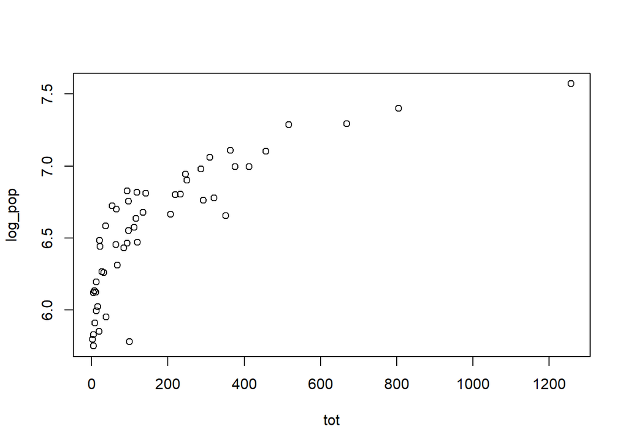

```r
log_pop <- log(pop, base=10)
tot <- murders$total
plot(tot,log_pop)
```

## 8. Histogram

Buat histogram dari populasi negara bagian.

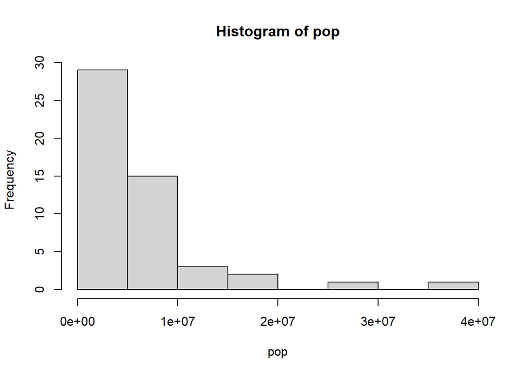

```r
hist(pop)
```

## 9. Boxplot

Hasilkan boxplot dari populasi negara bagian berdasarkan wilayahnya.

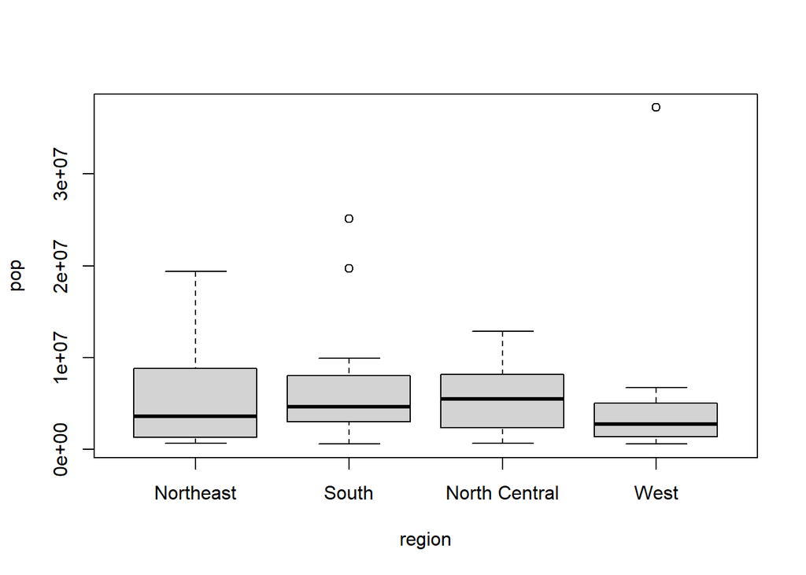

```r
boxplot(pop~region, data=murders)
```